# Proyecto 4 — Sistema de recomendación farmacéutico

Albert Gastelbondo, Mariana Carrillo, Valentina Cabarcas

2026-11-22

# FASE 1 — Reproducir el tutorial de Ander con Book-Crossing (Kaggle)

## 1.1 Lectura de datos

Los archivos de Kaggle usan punto y coma como separador y tienen columnas con nombres distintos al tutorial original. Se ajustan los nombres para que el resto del código funcione igual.

```r
books   <- read.csv("Books.csv",   sep = ";", stringsAsFactors = FALSE)
ratings <- read.csv("Ratings.csv", sep = ";", stringsAsFactors = FALSE)
users   <- read.csv("Users.csv",   sep = ";", stringsAsFactors = FALSE)

# Renombrar columnas para coincidir con el tutorial de Ander
# Books: ISBN, Author, Publisher ya existen; Title y Year también
# Ratings: User-ID → User.ID, Rating ya existe
# Users:   User-ID → User.ID, Age ya existe
names(ratings)[names(ratings) == "User.ID"]  <- "User.ID"   # por si acaso
names(ratings)[names(ratings) == "User-ID"]  <- "User.ID"
names(users)[names(users)     == "User-ID"]  <- "User.ID"

glimpse(books)
```

```
## Rows: 271,379
## Columns: 5
## $ ISBN      <chr> "0195153448", "0002005018", "0060973129", "0374157065", "039…
## $ Title     <chr> "Classical Mythology", "Clara Callan", "Decision in Normandy…
## $ Author    <chr> "Mark P. O. Morford", "Richard Bruce Wright", "Carlo D'Este"…
## $ Year      <int> 2002, 2001, 1991, 1999, 1999, 1991, 2000, 1993, 1996, 2002, …
## $ Publisher <chr> "Oxford University Press", "HarperFlamingo Canada", "HarperP…
```

```r
glimpse(ratings)
```

```
## Rows: 1,149,780
## Columns: 3
## $ User.ID <int> 276725, 276726, 276727, 276729, 276729, 276733, 276736, 276737…
## $ ISBN    <chr> "034545104X", "0155061224", "0446520802", "052165615X", "05217…
## $ Rating  <int> 0, 5, 0, 3, 6, 0, 8, 6, 7, 10, 0, 0, 0, 0, 0, 0, 9, 0, 0, 9, 8…
```

```r
glimpse(users)
```

```
## Rows: 278,859
## Columns: 2
## $ User.ID <chr> "1", "2", "3", "4", "5", "6", "7", "8", "9", "10", "11", "12",…
## $ Age     <chr> "", "18", "", "17", "", "61", "", "", "", "26", "14", "", "26"…
```

**Qué cambió al pasar del archivo original al de Kaggle:** - El separador es `;` en Kaggle (igual que el original de Friburgo). - La columna `User-ID` en Kaggle trae guion; se renombra a `User.ID`. - `Books.csv` de Kaggle tiene columnas: ISBN, Title, Author, Year, Publisher (el tutorial de Ander usaba Book.Author, Book.Publisher, etc.). Aquí ya vienen con nombres más limpios.

## 1.2 Formato de IDs (igual al tutorial)

```r
books$ISBN       <- paste0("Isbn.", books$ISBN)
users$User.ID    <- paste0("User.", users$User.ID)
ratings$ISBN     <- paste0("Isbn.", ratings$ISBN)
ratings$User.ID  <- paste0("User.", ratings$User.ID)
```

## 1.3 Exploración de calificaciones

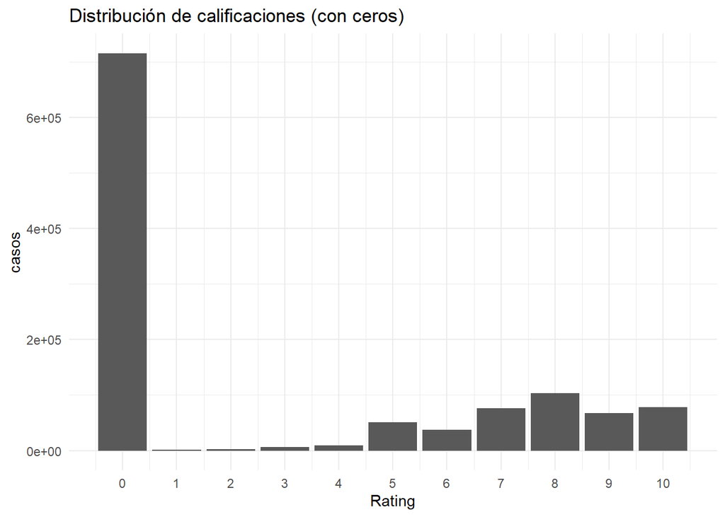

```r
# Distribución de ratings incluyendo 0
ratings %>%
  group_by(Rating) %>%
  summarise(casos = n()) %>%
  ggplot(aes(Rating, casos)) + geom_col() +
  theme_minimal() + scale_x_continuous(breaks = 0:10) +
  labs(title = "Distribución de calificaciones (con ceros)")
```

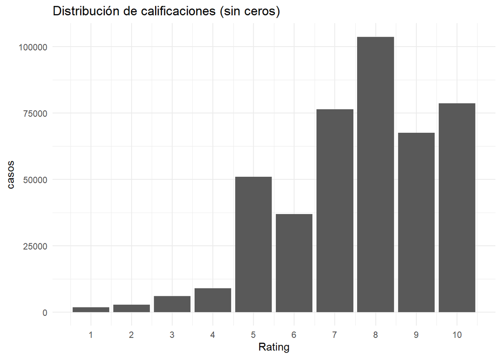

```r
# Eliminar ratings = 0 (sin valoración explícita)
ratings <- ratings[ratings$Rating != 0, ]

ratings %>%
  group_by(Rating) %>%
  summarise(casos = n()) %>%
  ggplot(aes(Rating, casos)) + geom_col() +
  theme_minimal() + scale_x_continuous(breaks = 1:10) +
  labs(title = "Distribución de calificaciones (sin ceros)")
```

**Por qué se eliminan los ceros:** un rating de 0 significa que el usuario no valoró explícitamente el libro, no que le desagradó. Incluirlos distorsionaría la similitud de coseno.

## 1.4 Filtrar usuarios poco activos

```r
ratings_sum <- ratings %>% group_by(User.ID) %>% count()
summary(ratings_sum$n)
```

```
##     Min.  1st Qu.   Median     Mean  3rd Qu.     Max.
##    1.000    1.000    1.000    5.574    3.000 8524.000
```

```r
# Quedarse solo con usuarios que han valorado más de 4 libros
user_index <- ratings_sum$User.ID[ratings_sum$n > 4]
users   <- users[users$User.ID %in% user_index, ]
ratings <- ratings[ratings$User.ID %in% user_index, ]
books   <- books[books$ISBN %in% ratings$ISBN, ]

rm(ratings_sum, user_index)
cat("Usuarios:", nrow(users), "| Libros:", nrow(books),
    "| Valoraciones:", nrow(ratings))
```

```
## Usuarios: 14220 | Libros: 132831 | Valoraciones: 340341
```

**Supuesto:** usuarios con 4 o menos valoraciones aportan poca información para medir similitud; filtrarlos reduce el costo computacional sin perder mucho.

## 1.5 Categorías aleatorias (como en el tutorial)

```r
set.seed(1234)
categorias <- c("Action and Adventure","Classic","Detective and Mystery","Fantasy")
books$category <- sample(categorias, nrow(books), replace = TRUE,
                         prob = c(0.25, 0.3, 0.25, 0.20))
books$category <- as.factor(books$category)
rm(categorias)
```

## 1.6 Recomendador 1: Basado en contenido (distancia de Gower)

```r
# Usar solo los primeros 10.000 libros para evitar matriz gigante
book_feature <- books[1:min(10000, nrow(books)), c("Author","Publisher","category")]
book_feature[,1] <- as.factor(book_feature[,1])
book_feature[,2] <- as.factor(book_feature[,2])
book_feature[,3] <- as.factor(book_feature[,3])

dissimilarity <- daisy(book_feature, metric = "gower", weights = c(2, 0.5, 1))
dissimilarity <- as.matrix(dissimilarity)
row.names(dissimilarity) <- books$ISBN[1:min(10000, nrow(books))]
colnames(dissimilarity)  <- books$ISBN[1:min(10000, nrow(books))]

# Función de recomendación por contenido
recomendar_contenido <- function(selected_books, dissimilarity_matrix, books_df,
                                 n_recommendations = 5) {
  idx <- which(colnames(dissimilarity_matrix) %in% selected_books$ISBN)
  results <- data.frame(dissimilarity_matrix[, idx],
                        recommended_book = row.names(dissimilarity_matrix),
                        stringsAsFactors = FALSE)
  results %>%
    pivot_longer(cols = -recommended_book, names_to = "readed_book",
                 values_to = "dissimilarity") %>%
    left_join(selected_books, by = c("recommended_book" = "ISBN")) %>%
    filter(recommended_book != readed_book, !is.na(Rating)) %>%
    mutate(similarity = 1 - dissimilarity,
           weighted_score = similarity * Rating) %>%
    filter(weighted_score > 0) %>%
    arrange(desc(weighted_score)) %>%
    group_by(recommended_book) %>% slice(1) %>%
    ungroup() %>%
    top_n(n_recommendations, weighted_score) %>%
    left_join(books_df, by = c("recommended_book" = "ISBN"))
}

# Probar con un usuario
user_id_prueba <- "User.1167"
user_books <- ratings %>%
  filter(User.ID == user_id_prueba & ISBN %in% books$ISBN[1:min(10000,nrow(books))]) %>%
  arrange(desc(Rating))
head(user_books, 5)
```

```
##     User.ID            ISBN Rating
## 1 User.1167 Isbn.0060929596     10
## 2 User.1167 Isbn.0802135196      9
## 3 User.1167 Isbn.0440224675      8
## 4 User.1167 Isbn.0679450548      7
## 5 User.1167 Isbn.0743230213      7
```

```r
selected_books <- user_books[, c("ISBN","Rating")]
if(nrow(selected_books) > 0) {
  rec_contenido <- recomendar_contenido(selected_books, dissimilarity, books)
  print(rec_contenido[, c("recommended_book","weighted_score")])
}
```

```
## # A tibble: 7 × 2
##   recommended_book weighted_score
##   <chr>                     <dbl>
## 1 Isbn.0373834985            1.43
## 2 Isbn.038533656X            1.43
## 3 Isbn.0440217520            1.43
## 4 Isbn.0440224675            2.29
## 5 Isbn.0679450548            2
## 6 Isbn.0743230213            2
## 7 Isbn.0802135196            2.57
```

## 1.7 Recomendador 2: Colaborativo ítem–ítem

```r
# Matriz usuario-producto (10.000 ratings para rapidez)
set.seed(42)
ratings_muestra <- ratings %>% sample_n(min(10000, nrow(ratings)))

user_item <- ratings_muestra %>%
  pivot_wider(names_from = ISBN, values_from = Rating) %>%
  as.data.frame()
row.names(user_item) <- user_item$User.ID
user_item$User.ID <- NULL
user_item <- as.matrix(user_item)

# Dispersión
sparsity_libros <- sum(is.na(user_item)) / (ncol(user_item) * nrow(user_item))
cat("Dispersión matriz libros:", round(sparsity_libros * 100, 2), "%\n")
```

```
## Dispersión matriz libros: 99.98 %
```

```r
# Similitud de coseno
cos_similarity <- function(A, B) {
  num <- sum(A * B, na.rm = TRUE)
  den <- sqrt(sum(A^2, na.rm = TRUE)) * sqrt(sum(B^2, na.rm = TRUE))
  if(den == 0) return(0)
  num / den
}

# Función ítem–ítem
item_recommendation <- function(book_id, rating_matrix = user_item,
                                 n_recommendations = 5) {
  if(!book_id %in% colnames(rating_matrix)) {
    cat("Producto no encontrado en la matriz\n"); return(NULL)
  }
  similarity <- apply(rating_matrix, 2,
                      FUN = function(y) cos_similarity(rating_matrix[, book_id], y))
  tibble(ISBN = names(similarity), similarity = similarity) %>%
    filter(ISBN != book_id) %>%
    arrange(desc(similarity)) %>%
    head(n_recommendations)
}

# Probar con un ISBN disponible
isbn_prueba <- colnames(user_item)[1]
rec_item <- item_recommendation(isbn_prueba)
print(rec_item)
```

```
## # A tibble: 5 × 2
##   ISBN            similarity
##   <chr>                <dbl>
## 1 Isbn.1863022325          1
## 2 Isbn.087196676X          1
## 3 Isbn.0696019957          1
## 4 Isbn.0397306326          1
## 5 Isbn.1564583023          1
```

**Qué hace:** para cada producto calcula la similitud de coseno con todos los demás usando los vectores de calificaciones de usuarios. Dos productos son similares si los mismos usuarios los calificaron de forma parecida.

## 1.8 Recomendador 3: Colaborativo usuario–usuario

```r
user_recommendation_books <- function(user_id, user_item_matrix = user_item,
                                       ratings_df = ratings,
                                       n_recommendations = 5,
                                       threshold = 1,
                                       nearest_neighbors = 10) {
  if(!user_id %in% rownames(user_item_matrix)) {
    cat("Usuario no encontrado\n"); return(NULL)
  }
  similarity <- apply(user_item_matrix, 1,
                      FUN = function(y) cos_similarity(user_item_matrix[user_id,], y))
  similar_users <- tibble(User.ID = names(similarity), similarity = similarity) %>%
    filter(User.ID != user_id) %>%
    arrange(desc(similarity)) %>%
    head(nearest_neighbors)

  ya_leidos <- ratings_df$ISBN[ratings_df$User.ID == user_id]

  ratings_df %>%
    filter(User.ID %in% similar_users$User.ID, !(ISBN %in% ya_leidos)) %>%
    group_by(ISBN) %>%
    summarise(count = n(), Rating = mean(Rating)) %>%
    filter(count > threshold) %>%
    arrange(desc(Rating), desc(count)) %>%
    head(n_recommendations)
}

usuario_prueba <- rownames(user_item)[1]
rec_user <- user_recommendation_books(usuario_prueba, n_recommendations = 10)
print(rec_user)
```

```
## # A tibble: 10 × 3
##    ISBN            count Rating
##    <chr>           <int>  <dbl>
##  1 Isbn.0060929790     2   10
##  2 Isbn.006440188X     2   10
##  3 Isbn.0140441166     2   10
##  4 Isbn.034531977X     2   10
##  5 Isbn.0451158717     2   10
##  6 Isbn.0552149519     2   10
##  7 Isbn.0553296981     2   10
##  8 Isbn.0875421857     2   10
##  9 Isbn.0552137030     2    9.5
## 10 Isbn.0553258478     2    9.5
```

**Qué hace:** encuentra los k usuarios más parecidos (mismos cosenos a nivel de fila), luego recomienda lo que esos usuarios compraron y el usuario objetivo todavía no. El parámetro `threshold` exige que al menos 2 vecinos hayan comprado el producto.

# FASE 2 — Cargar, limpiar y unir datos Procaps

```r
cab  <- read_csv2("cab.csv",
                  locale = locale(encoding = "latin1", grouping_mark = "."),
                  col_types = cols(invoice    = col_character(),
                                   colaborador = col_character()))

pro2 <- read_csv2("pro2.csv",
                  locale = locale(encoding = "latin1", grouping_mark = "."),
                  col_types = cols(invoice  = col_character(),
                                   Material = col_character()))

cat("cab  — filas:", nrow(cab),  "| columnas:", ncol(cab), "\n")
```

```
## cab  — filas: 251054 | columnas: 6
```

```r
cat("pro2 — filas:", nrow(pro2), "| columnas:", ncol(pro2), "\n")
```

```
## pro2 — filas: 496375 | columnas: 12
```

```r
# Left join: conservamos todas las líneas de pro2 que tengan cabecera
farma <- pro2 %>%
  left_join(cab, by = "invoice")

cat("Tabla unida — filas:", nrow(farma), "\n")
```

```
## Tabla unida — filas: 496375
```

```r
# ¿Se pierden filas? (invoices en pro2 sin cabecera)
sin_cab <- pro2 %>% anti_join(cab, by = "invoice")
cat("Líneas de pro2 sin cabecera:", nrow(sin_cab), "\n")
```

```
## Líneas de pro2 sin cabecera: 0
```

```r
# ¿Se duplican? El join no debería multiplicar filas si invoice es único en cab
duplicadas <- nrow(farma) - nrow(pro2)
cat("Diferencia de filas:", duplicadas,
    "(0 = no se duplicaron)\n")
```

```
## Diferencia de filas: 0 (0 = no se duplicaron)
```

**Por qué left join:** queremos conservar todas las líneas de detalle (`pro2`). Si usáramos inner join perderíamos líneas que no tienen cabecera. Un right join o full join no tiene sentido porque la unidad de análisis es cada línea de producto.

```r
# Convertir fecha
farma$fecha <- as.Date(farma$fecha, format = "%d/%m/%Y")

# Resumen descriptivo
cat("Periodo:", format(min(farma$fecha, na.rm=TRUE)),
    "a", format(max(farma$fecha, na.rm=TRUE)), "\n")
```

```
## Periodo: 2013-07-12 a 2022-03-25
```

```r
cat("Compradores únicos:", n_distinct(farma$colaborador), "\n")
```

```
## Compradores únicos: 5888
```

```r
cat("Productos únicos:",   n_distinct(farma$Material), "\n")
```

```
## Productos únicos: 732
```

```r
cat("Facturas únicas:",    n_distinct(farma$invoice), "\n")
```

```
## Facturas únicas: 250748
```

```r
# Distribución de cantidad
summary(farma$cantidad)
```

```
##    Min. 1st Qu.  Median    Mean 3rd Qu.    Max.
##   1.000   1.000   1.000   1.486   2.000  20.000
```

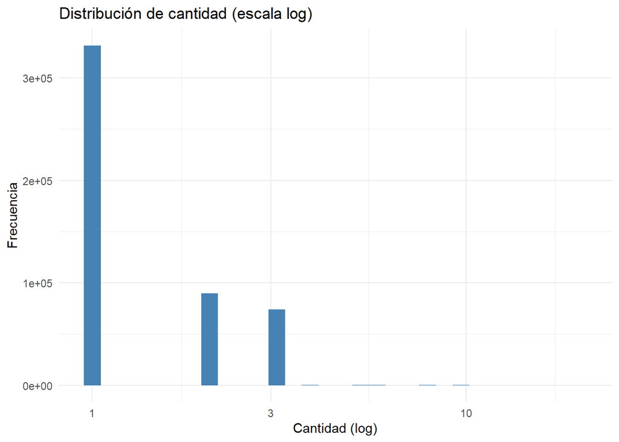

```r
ggplot(farma, aes(x = cantidad)) +
  geom_histogram(bins = 30, fill = "steelblue") +
  scale_x_log10() +
  labs(title = "Distribución de cantidad (escala log)",
       x = "Cantidad (log)", y = "Frecuencia") +
  theme_minimal()
```

# FASE 3 — Preferencia implícita y matriz usuario–producto

```r
# Agregar por comprador y producto
pref <- farma %>%
  group_by(colaborador, Material) %>%
  summarise(
    suma_cantidad  = sum(cantidad, na.rm = TRUE),
    n_facturas     = n_distinct(invoice),
    binario        = 1,
    log_cantidad   = log1p(sum(cantidad, na.rm = TRUE)),
    .groups = "drop"
  )

# Comparar las cuatro definiciones de preferencia
cat("--- suma_cantidad ---\n"); summary(pref$suma_cantidad)
```

```
## --- suma_cantidad ---
```

```
##    Min. 1st Qu.  Median    Mean 3rd Qu.    Max.
##   1.000   1.000   2.000   3.409   3.000 263.000
```

```r
cat("--- n_facturas ---\n");    summary(pref$n_facturas)
```

```
## --- n_facturas ---
```

```
##    Min. 1st Qu.  Median    Mean 3rd Qu.    Max.
##   1.000   1.000   1.000   2.284   2.000  88.000
```

```r
cat("--- log_cantidad ---\n");  summary(pref$log_cantidad)
```

```
## --- log_cantidad ---
```

```
##    Min. 1st Qu.  Median    Mean 3rd Qu.    Max.
##  0.6931  0.6931  1.0986  1.1873  1.3863  5.5759
```

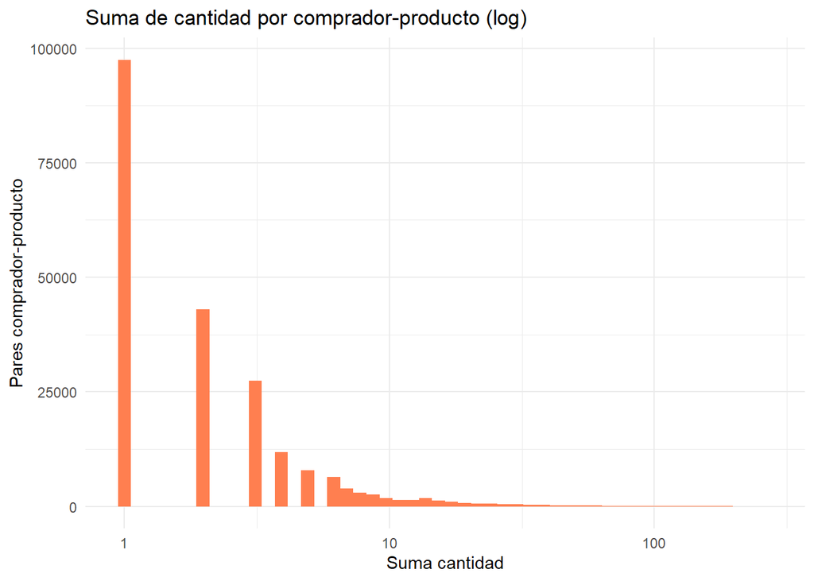

```r
# Visualizar cola larga de suma_cantidad
ggplot(pref, aes(x = suma_cantidad)) +
  geom_histogram(bins = 50, fill = "coral") +
  scale_x_log10() +
  labs(title = "Suma de cantidad por comprador-producto (log)",
       x = "Suma cantidad", y = "Pares comprador-producto") +
  theme_minimal()
```

**Definición elegida: `log1p(cantidad)`**

La suma directa de cantidad permite que un mayorista que compra 263 unidades domine completamente la similitud de coseno. Con `log(1 + cantidad)` se conserva el orden (más compras = más preferencia) pero se comprime la escala, haciendo que la diferencia entre comprar 1 y 2 unidades sea proporcional a la diferencia entre 100 y 200. Además no hay valores negativos ni ceros.

```r
# Construir la matriz usuario-producto con log_cantidad
user_item_farma <- pref %>%
  select(colaborador, Material, log_cantidad) %>%
  pivot_wider(names_from = Material, values_from = log_cantidad,
              values_fill = 0) %>%
  as.data.frame()

row.names(user_item_farma) <- user_item_farma$colaborador
user_item_farma$colaborador <- NULL
user_item_farma <- as.matrix(user_item_farma)

# Dispersión real (celdas = 0 sobre total)
sparsity_farma <- sum(user_item_farma == 0) /
                  (nrow(user_item_farma) * ncol(user_item_farma))
cat("Compradores:", nrow(user_item_farma),
    "| Productos:", ncol(user_item_farma), "\n")
```

```
## Compradores: 5888 | Productos: 732
```

```r
cat("Dispersión:", round(sparsity_farma * 100, 2), "%\n")
```

```
## Dispersión: 94.98 %
```

# FASE 4 — Similitud de coseno

```r
# Función de similitud de coseno (reutilizada, ahora sin NA porque la matriz
# ya tiene 0 en lugar de NA)
cos_sim_farma <- function(A, B) {
  num <- sum(A * B)
  den <- sqrt(sum(A^2)) * sqrt(sum(B^2))
  if(den == 0) return(0)
  num / den
}

# Precalcular matriz producto-producto completa (732 × 732)
# Puede tardar 1-2 minutos
cat("Calculando matriz producto-producto...\n")
```

```
## Calculando matriz producto-producto...
```

```r
mat_t <- t(user_item_farma)   # productos en filas, compradores en columnas
n_prod <- nrow(mat_t)

sim_matrix <- matrix(0, nrow = n_prod, ncol = n_prod,
                     dimnames = list(rownames(mat_t), rownames(mat_t)))

for(i in 1:n_prod) {
  for(j in i:n_prod) {
    s <- cos_sim_farma(mat_t[i,], mat_t[j,])
    sim_matrix[i,j] <- s
    sim_matrix[j,i] <- s
  }
}
cat("Matriz producto-producto calculada.\n")
```

```
## Matriz producto-producto calculada.
```

```r
# Validación contra lsa::cosine en 3 pares
prod_nombres <- rownames(sim_matrix)
set.seed(7)
pares <- sample(1:n_prod, 6)

for(k in seq(1, 6, by=2)) {
  p1 <- pares[k]; p2 <- pares[k+1]
  manual <- sim_matrix[p1, p2]
  lsa_v  <- lsa::cosine(mat_t[p1,], mat_t[p2,])
  cat(prod_nombres[p1], "vs", prod_nombres[p2],
      "| Manual:", round(manual,4), "| lsa:", round(lsa_v,4),
      "| Coinciden:", isTRUE(all.equal(manual, lsa_v, tol=1e-6)), "\n")
}
```

```
## 300001231 vs 300001881 | Manual: 0.0688 | lsa: 0.0688 | Coinciden: FALSE
## 300011302 vs 300005131 | Manual: 0.0201 | lsa: 0.0201 | Coinciden: FALSE
## 300001470 vs 300000301 | Manual: 0 | lsa: 0 | Coinciden: FALSE
```

**Significado geométrico de coseno = 0.8:** los vectores de compras de dos productos forman un ángulo de ~37°. Significa que los mismos compradores tienden a adquirir ambos productos en proporciones similares. No importa cuánto compren en total, solo el patrón relativo.

# FASE 5 — Recomendador ítem–ítem Procaps

```r
# Catálogo de productos con descripción
catalogo <- pro2 %>%
  select(Material, description) %>%
  distinct(Material, .keep_all = TRUE)

item_recommendation_farma <- function(material_id,
                                       sim_mat = sim_matrix,
                                       n_recommendations = 10) {
  if(!material_id %in% rownames(sim_mat)) {
    cat("Producto no encontrado:", material_id, "\n"); return(NULL)
  }
  sims <- sim_mat[material_id, ]
  tibble(Material = names(sims), similarity = sims) %>%
    filter(Material != material_id) %>%
    arrange(desc(similarity)) %>%
    head(n_recommendations) %>%
    left_join(catalogo, by = "Material")
}

# Analizar cinco productos con códigos y presentaciones diferentes
# Se usan los mismos cinco casos del informe.
# El IVA no se utiliza como categoría farmacéutica ni para repetir productos.
productos_prueba <- tibble::tibble(
  Material = c(
    "300000012",
    "300000057",
    "300000089",
    "300005269",
    "300005439"
  ),
  presentacion = c(
    "Cápsulas blandas",
    "Solución oftálmica",
    "Inyectable",
    "Crema",
    "Nutrición en sobres"
  )
) %>%
  left_join(catalogo, by = "Material")

# Verificar que hay cinco productos distintos, descritos y presentes en el modelo
stopifnot(
  nrow(productos_prueba) == 5,
  n_distinct(productos_prueba$Material) == 5,
  !anyNA(productos_prueba$description),
  all(productos_prueba$Material %in% rownames(sim_matrix))
)

print(productos_prueba, n = Inf)
```

```
## # A tibble: 5 × 3
##   Material  presentacion        description
##   <chr>     <chr>               <chr>
## 1 300000012 Cápsulas blandas    B-VIT CBG CAJA x 50 UND CIAL
## 2 300000057 Solución oftálmica  LAGRIFRESH SOL. OFTAL. FCO x 15ml
## 3 300000089 Inyectable          B-VIT PLUS INY. CAJA x 6 AMPOLLAS
## 4 300005269 Crema               FUNGIBLAN CREMA TUBO COLAPSIBLEx 30 g
## 5 300005439 Nutrición en sobres NUTRIGEL 2.0 SABOR NRJA CJAx30SOBRE CIAL
```

```r
tabla_analisis <- list()
for(i in 1:nrow(productos_prueba)) {
  mid <- productos_prueba$Material[i]
  recs <- item_recommendation_farma(mid, n_recommendations = 5)
  if(!is.null(recs)) {
    recs$producto_consulta <- productos_prueba$description[i]
    tabla_analisis[[i]] <- recs
  }
}
tabla_item_item <- bind_rows(tabla_analisis)
# Mostrar las 25 filas: cinco recomendaciones por cada producto consultado
print(
  tabla_item_item[, c(
    "producto_consulta",
    "description",
    "similarity"
  )],
  n = Inf
)
```

```
## # A tibble: 25 × 3
##    producto_consulta                        description               similarity
##    <chr>                                    <chr>                          <dbl>
##  1 B-VIT CBG CAJA x 50 UND CIAL             GINKGO BILOBA 40 mg CBG …      0.628
##  2 B-VIT CBG CAJA x 50 UND CIAL             VITAMINA E 400 UI FCO x …      0.620
##  3 B-VIT CBG CAJA x 50 UND CIAL             NUTRIGEL 2.0 SABOR NRJA …      0.594
##  4 B-VIT CBG CAJA x 50 UND CIAL             VITAMINA E 1000 UI FCO x…      0.593
##  5 B-VIT CBG CAJA x 50 UND CIAL             GESTAVIT DHA CBG CAJA x …      0.570
##  6 LAGRIFRESH SOL. OFTAL. FCO x 15ml        GINKGO BILOBA 40 mg CBG …      0.547
##  7 LAGRIFRESH SOL. OFTAL. FCO x 15ml        TEARSOFT SOL OFT CJAx1 F…      0.535
##  8 LAGRIFRESH SOL. OFTAL. FCO x 15ml        VITAMINA E 400 UI FCO x …      0.532
##  9 LAGRIFRESH SOL. OFTAL. FCO x 15ml        VITAMINA E 1000 UI FCO x…      0.524
## 10 LAGRIFRESH SOL. OFTAL. FCO x 15ml        NUTRIGEL 2.0 SABOR NRJA …      0.519
## 11 B-VIT PLUS INY. CAJA x 6 AMPOLLAS        B-VIT INY.CJAx3 JERINGA …      0.477
## 12 B-VIT PLUS INY. CAJA x 6 AMPOLLAS        VITAMINA E 1000 UI FCO x…      0.458
## 13 B-VIT PLUS INY. CAJA x 6 AMPOLLAS        GINKGO BILOBA 40 mg CBG …      0.458
## 14 B-VIT PLUS INY. CAJA x 6 AMPOLLAS        VITAMINA E 400 UI FCO x …      0.446
## 15 B-VIT PLUS INY. CAJA x 6 AMPOLLAS        B-VIT CBG CAJA x 50 UND …      0.445
## 16 FUNGIBLAN CREMA TUBO COLAPSIBLEx 30 g    OMEGEL CBG CJA x 10 UND …      0.396
## 17 FUNGIBLAN CREMA TUBO COLAPSIBLEx 30 g    POLIVIT CBG CJA x 10 UND…      0.332
## 18 FUNGIBLAN CREMA TUBO COLAPSIBLEx 30 g    TENIBLAN 30-200 CBG CJA …      0.317
## 19 FUNGIBLAN CREMA TUBO COLAPSIBLEx 30 g    KETOBLAN 50 mg CBG CJAx …      0.299
## 20 FUNGIBLAN CREMA TUBO COLAPSIBLEx 30 g    AMICAPS 20.8% EC VET. FC…      0.293
## 21 NUTRIGEL 2.0 SABOR NRJA CJAx30SOBRE CIAL NUTRIGEL 2.0 SABOR NTRO …      0.751
## 22 NUTRIGEL 2.0 SABOR NRJA CJAx30SOBRE CIAL NUTRIGEL ADVANCE MANDARI…      0.682
## 23 NUTRIGEL 2.0 SABOR NRJA CJAx30SOBRE CIAL VITAMINA E 400 UI FCO x …      0.675
## 24 NUTRIGEL 2.0 SABOR NRJA CJAx30SOBRE CIAL DICLOFEN AEROSOL FCO X 2…      0.661
## 25 NUTRIGEL 2.0 SABOR NRJA CJAx30SOBRE CIAL VITAMINA E 1000 UI FCO x…      0.660
```

# FASE 6 — Recomendador usuario–usuario Procaps

```r
user_recommendation_farma <- function(colaborador_id,
                                       user_item_mat = user_item_farma,
                                       pref_df = pref,
                                       n_recommendations = 10,
                                       nearest_neighbors = 10,
                                       threshold = 1) {

  if(!colaborador_id %in% rownames(user_item_mat)) {
    cat("Comprador no encontrado\n"); return(NULL)
  }

  # Similitud con todos los demás compradores
  similarity <- apply(user_item_mat, 1,
                      FUN = function(y) cos_sim_farma(user_item_mat[colaborador_id,], y))

  vecinos <- tibble(colaborador = names(similarity), similarity = similarity) %>%
    filter(colaborador != colaborador_id) %>%
    arrange(desc(similarity)) %>%
    head(nearest_neighbors)

  # Productos que el comprador YA ha comprado
  ya_comprados <- pref_df$Material[pref_df$colaborador == colaborador_id]

  # Productos que sus vecinos compraron y él no
  pref_df %>%
    filter(colaborador %in% vecinos$colaborador,
           !(Material %in% ya_comprados)) %>%
    group_by(Material) %>%
    summarise(n_vecinos    = n_distinct(colaborador),
              log_cant_avg = mean(log_cantidad),
              .groups = "drop") %>%
    filter(n_vecinos >= threshold) %>%
    arrange(desc(n_vecinos), desc(log_cant_avg)) %>%
    head(n_recommendations) %>%
    left_join(catalogo, by = "Material")
}

# Probar con un comprador concreto
comprador_prueba <- rownames(user_item_farma)[1]
recs_usuario <- user_recommendation_farma(comprador_prueba)
print(recs_usuario)
```

```
## # A tibble: 4 × 4
##   Material  n_vecinos log_cant_avg description
##   <chr>         <int>        <dbl> <chr>
## 1 300001231         1        0.693 MELOXICAM 15 mg TAB CJA x 10 UND CIAL
## 2 300001236         1        0.693 OMEGA 3 CBG CJA x 30 UND CIAL
## 3 300001461         1        0.693 ALAP SOL OFT CJAx1 FCOx3 mL CIAL
## 4 300001521         1        0.693 EPAX 720 mg CBG EC CJA x 50 UND CIAL
```

```r
# Verificar que NO aparecen productos ya comprados
ya_comp <- pref$Material[pref$colaborador == comprador_prueba]
cat("Productos ya comprados en las recomendaciones:",
    sum(recs_usuario$Material %in% ya_comp), "(debe ser 0)\n")
```

```
## Productos ya comprados en las recomendaciones: 0 (debe ser 0)
```

```r
# Análisis de sensibilidad a k
for(k in c(5, 10, 20)) {
  r <- user_recommendation_farma(comprador_prueba, nearest_neighbors = k,
                                  n_recommendations = 5)
  cat("k =", k, "→", nrow(r), "recomendaciones |",
      "Top:", r$description[1], "\n")
}
```

```
## k = 5 → 0 recomendaciones | Top: NA
## k = 10 → 4 recomendaciones | Top: MELOXICAM 15 mg TAB CJA x 10 UND CIAL
## k = 20 → 5 recomendaciones | Top: VITAMINA E 1000 UI FCO x 30 CBG
```

# FASE 7 — Evaluación temporal contra línea base

Se evaluaron los tres métodos con una partición temporal: entrenamiento hasta el 31 de diciembre de 2020 y prueba de enero de 2021 a marzo de 2022. Se excluyen las compras anteriores, se usa la misma cohorte y se ofrecen como máximo diez recomendaciones por método.

## 7.1 Partición temporal

```r
# Partición temporal: las recomendaciones usan exclusivamente datos de train.
farma_train <- farma %>% filter(fecha <= as.Date("2020-12-31"))
farma_test  <- farma %>% filter(fecha >  as.Date("2020-12-31"))

compradores_ambos <- intersect(
  unique(farma_train$colaborador), unique(farma_test$colaborador)
)

cat("Compradores en train:", n_distinct(farma_train$colaborador), "\n")
cat("Compradores en test:", n_distinct(farma_test$colaborador), "\n")
cat("Compradores presentes en ambos periodos:", length(compradores_ambos), "\n")
```

```
## Compradores en train: 5255
## Compradores en test: 3201
## Compradores presentes en ambos periodos: 2568
```

## 7.2 Matrices calculadas exclusivamente con entrenamiento

```r
# Reconstrucción sin filtración de información de test.
pref_train <- farma_train %>%
  group_by(colaborador, Material) %>%
  summarise(log_cantidad = log1p(sum(cantidad, na.rm = TRUE)), .groups = "drop")

user_item_train <- pref_train %>%
  pivot_wider(names_from = Material, values_from = log_cantidad,
              values_fill = 0) %>%
  as.data.frame()
row.names(user_item_train) <- user_item_train$colaborador
user_item_train$colaborador <- NULL
user_item_train <- as.matrix(user_item_train)

# Similitud ítem–ítem, exclusivamente con las transacciones de train.
mat_t_train <- t(user_item_train)
normas_prod <- sqrt(rowSums(mat_t_train^2))
mat_t_norm <- sweep(mat_t_train, 1, pmax(normas_prod, .Machine$double.eps), "/")
sim_train <- tcrossprod(mat_t_norm)

# Similitud usuario–usuario, con el mismo coseno definido en la FASE 4.
normas_usuario <- sqrt(rowSums(user_item_train^2))
user_item_train_norm <- sweep(
  user_item_train, 1, pmax(normas_usuario, .Machine$double.eps), "/"
)
sim_usuarios_train <- tcrossprod(user_item_train_norm)

cat("Matriz de productos:", nrow(sim_train), "x", ncol(sim_train), "\n")
cat("Matriz de compradores:", nrow(sim_usuarios_train), "x",
    ncol(sim_usuarios_train), "\n")
```

```
## Matriz de productos: 732 x 732
## Matriz de compradores: 5255 x 5255
```

## 7.3 Línea base corregida: filtrar antes de seleccionar diez

```r
# Importante: ordenar TODOS los productos de train por unidades vendidas.
# La exclusión del historial se hace ANTES de seleccionar las diez posiciones
# de cada comprador; así la línea base no deja huecos artificiales.
ranking_popularidad <- farma_train %>%
  group_by(Material) %>%
  summarise(total = sum(cantidad, na.rm = TRUE), .groups = "drop") %>%
  arrange(desc(total)) %>%
  pull(Material)

cat("Diez primeros productos en el ranking global:",
    paste(head(ranking_popularidad, 10), collapse = ", "), "\n")
```

```
## Diez primeros productos en el ranking global: 300000712, 300001554, 300000869, 300005439, 300000714, 300004184, 300001535, 300005440, 300000740, 300000848
```

## 7.4 Evaluación de los 2.533 compradores elegibles

```r
# Lista de productos por comprador para no consultar el CSV a cada iteración.
compras_train <- split(pref_train$Material, pref_train$colaborador)
compras_test <- split(farma_test$Material, farma_test$colaborador)

compradores_elegibles <- compradores_ambos[vapply(compradores_ambos, function(u) {
  length(setdiff(unique(compras_test[[u]]), compras_train[[u]])) > 0
}, logical(1))]

cat("Compradores evaluables:", length(compradores_elegibles), "\n")
cat("Excluidos por no adquirir productos nuevos:",
    length(compradores_ambos) - length(compradores_elegibles), "\n")
stopifnot(length(compradores_elegibles) > 0)

# Los mismos compradores y la misma verdad de prueba para los tres métodos.
evaluar_comprador <- function(colab) {
  ya_comprados <- compras_train[[colab]]
  nuevos_test <- setdiff(unique(compras_test[[colab]]), ya_comprados)
  stopifnot(length(nuevos_test) > 0)

  # 1. Ítem–ítem: primer código del historial agregado en train como semilla.
  semilla <- ya_comprados[1]
  rec_item <- tibble(
    Material = colnames(sim_train),
    sim = as.numeric(sim_train[semilla, ])
  ) %>%
    filter(!(Material %in% ya_comprados)) %>%
    arrange(desc(sim)) %>%
    slice_head(n = 10) %>%
    pull(Material)

  # 2. Usuario–usuario: los diez vecinos más similares en train, excluido él.
  similitudes <- sim_usuarios_train[colab, ]
  orden_vecinos <- order(-similitudes, seq_along(similitudes))
  vecinos <- names(similitudes)[orden_vecinos]
  vecinos <- head(vecinos[vecinos != colab], 10)
  rec_usuario <- pref_train %>%
    filter(colaborador %in% vecinos, !(Material %in% ya_comprados)) %>%
    group_by(Material) %>%
    summarise(n_vecinos = n_distinct(colaborador),
              log_cant_avg = mean(log_cantidad), .groups = "drop") %>%
    arrange(desc(n_vecinos), desc(log_cant_avg)) %>%
    slice_head(n = 10) %>%
    pull(Material)

  # 3. Más vendidos: filtrar historial ANTES de tomar diez productos.
  rec_baseline <- head(
    ranking_popularidad[!(ranking_popularidad %in% ya_comprados)], 10
  )

  recomendaciones <- list(item = rec_item, usuario = rec_usuario,
                          baseline = rec_baseline)
  bind_rows(lapply(names(recomendaciones), function(metodo) {
    recs <- recomendaciones[[metodo]]
    n_aciertos <- sum(recs %in% nuevos_test)
    tibble(colaborador = colab, metodo = metodo,
           hit = as.integer(n_aciertos > 0),
           precision = n_aciertos / 10)
  }))
}

resultados_eval <- bind_rows(lapply(compradores_elegibles, evaluar_comprador))
stopifnot(nrow(resultados_eval) == 3 * length(compradores_elegibles))
cat("Registros de evaluación (comprador x método):", nrow(resultados_eval), "\n")
```

```
## Compradores evaluables: 2533
## Excluidos por no adquirir productos nuevos: 35
## Registros de evaluación (comprador x método): 7599
```

El acierto@10 requiere al menos una coincidencia con compras nuevas. La precisión@10 divide el número de coincidencias entre diez, incluso cuando la lista sea más corta. Los intervalos de acierto son de **Wilson**; los de precisión y diferencias pareadas se calculan mediante bootstrap de compradores (10.000 remuestras, semilla 2026).

## 7.5 Intervalos de confianza y comparaciones pareadas

```r
z <- qnorm(0.975)
resumen_eval <- resultados_eval %>%
  group_by(metodo) %>%
  summarise(n = n(), aciertos = sum(hit), hit_rate = mean(hit),
            precision = mean(precision), .groups = "drop") %>%
  mutate(
    # Wilson (no es el intervalo normal de Wald).
    centro_w = (hit_rate + z^2 / (2*n)) / (1 + z^2/n),
    margen_w = z * sqrt(hit_rate*(1-hit_rate)/n + z^2/(4*n^2)) /
      (1 + z^2/n),
    hit_ic_inf = centro_w - margen_w,
    hit_ic_sup = centro_w + margen_w
  )

# Una única matriz de remuestras para conservar el apareamiento por comprador.
metricas_pareadas <- resultados_eval %>%
  select(colaborador, metodo, hit, precision) %>%
  pivot_wider(names_from = metodo, values_from = c(hit, precision))
metricas_pareadas <- metricas_pareadas[
  match(compradores_elegibles, metricas_pareadas$colaborador), , drop = FALSE
]
stopifnot(!anyNA(metricas_pareadas))

set.seed(2026)
n_eval <- nrow(metricas_pareadas)
n_boot <- 10000L
indices_boot <- replicate(n_boot, sample.int(n_eval, n_eval, replace = TRUE))
ic_bootstrap <- function(valores) {
  medias <- colMeans(matrix(valores[indices_boot], nrow = n_eval))
  unname(quantile(medias, probs = c(0.025, 0.975)))
}

resumen_eval$prec_ic_inf <- vapply(resumen_eval$metodo, function(m) {
  ic_bootstrap(metricas_pareadas[[paste0("precision_", m)]])[1]
}, numeric(1))
resumen_eval$prec_ic_sup <- vapply(resumen_eval$metodo, function(m) {
  ic_bootstrap(metricas_pareadas[[paste0("precision_", m)]])[2]
}, numeric(1))

comparacion_pareada <- bind_rows(lapply(c("item", "usuario"), function(m) {
  d_hit <- metricas_pareadas[[paste0("hit_", m)]] - metricas_pareadas$hit_baseline
  d_prec <- metricas_pareadas[[paste0("precision_", m)]] -
    metricas_pareadas$precision_baseline
  ci_hit <- ic_bootstrap(d_hit)
  ci_prec <- ic_bootstrap(d_prec)
  tibble(metodo = m, diferencia_hit = mean(d_hit),
         hit_ic_inf = ci_hit[1], hit_ic_sup = ci_hit[2],
         diferencia_precision = mean(d_prec),
         prec_ic_inf = ci_prec[1], prec_ic_sup = ci_prec[2])
}))
```

```r
orden_metodos <- c("item", "usuario", "baseline")
resumen_eval <- resumen_eval %>%
  mutate(metodo = factor(metodo, levels = orden_metodos)) %>%
  arrange(metodo)

resumen_publicable <- resumen_eval %>%
  transmute(
    Método = recode(as.character(metodo), item = "Ítem–ítem",
                    usuario = "Usuario–usuario", baseline = "Más vendidos"),
    Compradores = n,
    `Acierto@10` = sprintf("%.2f %%", 100 * hit_rate),
    `IC 95 % acierto (Wilson)` = sprintf("[%.2f; %.2f] %%",
                                     100 * hit_ic_inf, 100 * hit_ic_sup),
    `Precisión@10` = sprintf("%.2f %%", 100 * precision),
    `IC 95 % precisión (bootstrap)` = sprintf("[%.2f; %.2f] %%",
                                            100 * prec_ic_inf, 100 * prec_ic_sup)
  )
knitr::kable(resumen_publicable, caption = "Evaluación temporal sobre todos los compradores elegibles")

comparacion_publicable <- comparacion_pareada %>%
  transmute(
    Método = recode(metodo, item = "Ítem–ítem", usuario = "Usuario–usuario"),
    `Diferencia acierto (pp)` = sprintf("%.2f", 100*diferencia_hit),
    `IC 95 % acierto (pp)` = sprintf("[%.2f; %.2f]",
                                  100*hit_ic_inf, 100*hit_ic_sup),
    `Diferencia precisión (pp)` = sprintf("%.3f", 100*diferencia_precision),
    `IC 95 % precisión (pp)` = sprintf("[%.3f; %.3f]",
                                    100*prec_ic_inf, 100*prec_ic_sup)
  )
knitr::kable(comparacion_publicable,
             caption = "Diferencias pareadas frente a la línea base de más vendidos")
```

Tabla 4. Evaluación temporal sobre 2.533 compradores elegibles

| Método | Compradores | Acierto@10 | IC 95 % acierto (Wilson) | Precisión@10 | IC 95 % precisión (bootstrap) |
| --- | --- | --- | --- | --- | --- |
| Ítem–ítem | 2.533 | 58,47 % | [56,54; 60,37] % | 10,56 % | [10,09; 11,03] % |
| Usuario–usuario | 2.533 | 60,52 % | [58,60; 62,41] % | 10,87 % | [10,41; 11,32] % |
| Más vendidos | 2.533 | 63,40 % | [61,51; 65,26] % | 11,24 % | [10,79; 11,69] % |

Diferencias pareadas frente a más vendidos

| Método | Diferencia acierto (pp) | IC 95 % acierto (pp) | Diferencia precisión (pp) | IC 95 % precisión (pp) |
| --- | --- | --- | --- | --- |
| Ítem–ítem | -4,93 | [-6,55; -3,32] | -0,675 | [-0,991; -0,367] |
| Usuario–usuario | -2,88 | [-4,70; -1,07] | -0,371 | [-0,758; 0,004] |

## 7.6 Comparación gráfica

[figure not shown]

```r
ggplot(resumen_eval, aes(x = metodo, y = hit_rate,
                         ymin = hit_ic_inf, ymax = hit_ic_sup,
                         fill = metodo)) +
  geom_col(width = 0.65) +
  geom_errorbar(width = 0.18) +
  scale_x_discrete(labels = c(item = "Ítem–ítem",
                              usuario = "Usuario–usuario",
                              baseline = "Más vendidos")) +
  scale_y_continuous(labels = scales::percent_format(accuracy = 1),
                     limits = c(0, 0.75)) +
  labs(title = "Acierto@10 por método (2.533 compradores)",
       subtitle = "Intervalos de confianza de Wilson al 95 %",
       y = "Acierto@10", x = "") +
  theme_minimal() + theme(legend.position = "none")
```

**Interpretación.** Más vendidos alcanza el mayor acierto (63,40 %), seguido de usuario–usuario (60,52 %) e ítem–ítem (58,47 %). Las diferencias pareadas de acierto frente a la línea base son negativas, por lo que esta prueba no demuestra superioridad de la personalización. Estas recomendaciones comerciales no suponen equivalencia terapéutica ni validación clínica.

```
# Exportar historial de compradores
historial_export <- farma %>%
  group_by(colaborador) %>%
  summarise(
    n_facturas = n_distinct(invoice),
    n_productos = n_distinct(Material),
    primera_compra = min(fecha, na.rm = TRUE),
    ultima_compra = max(fecha, na.rm = TRUE),
    productos = list(
      farma %>%
        filter(colaborador == cur_group_id()) %>%
        distinct(Material, description) %>%
        head(50)
    )
  )

# Versión más simple y útil para el prototipo
historial_simple <- farma %>%
  group_by(colaborador, Material, description) %>%
  summarise(
    total_unidades = sum(cantidad, na.rm = TRUE),
    n_compras = n_distinct(invoice),
    .groups = "drop"
  ) %>%
  arrange(colaborador, desc(total_unidades))

write_csv(historial_simple, "historial_compradores.csv")
```

# Exportar resultados para el prototipo

```r
# Exportar top-10 recomendaciones ítem–ítem para todos los productos
recomendaciones_export <- lapply(rownames(sim_matrix), function(mid) {
  recs <- item_recommendation_farma(mid, n_recommendations = 10)
  if(is.null(recs)) return(NULL)
  list(
    material    = mid,
    description = catalogo$description[catalogo$Material == mid][1],
    recomendaciones = recs[, c("Material","description","similarity")]
  )
})
recomendaciones_export <- Filter(Negate(is.null), recomendaciones_export)

write_json(recomendaciones_export, "recomendaciones_item.json", pretty = TRUE)

# Exportar también el catálogo de productos
write_csv(catalogo, "catalogo_productos.csv")

cat("Archivos exportados: recomendaciones_item.json y catalogo_productos.csv\n")
```

```
## Archivos exportados: recomendaciones_item.json y catalogo_productos.csv
```